# Data Science and Analytics 2022

İrem Uslu - 170709043

```r
  library(ggplot2)
  library(tidyverse)
  library(dplyr)
  library(plyr)
```

### 1) Download the dataset from the link below and import the dataset to R as a dataframe named *‘alcohol_data’*.

*https://www.kaggle.com/datasets/whenamancodes/alcohol-effects-on-study*

```r
    alcohol_data <- read.csv("Portuguese.csv" , header = TRUE , sep = ",")
```

### 2)

#### A) Create a new dataframe as *‘alcohol_data_small’* from *‘alcohol_data’* by choosing at least 5 columns (at least one factor and one numeric).

```r
  alcohol_data_small <- alcohol_data [, c(1:4,6,13:14,16:17,27:28,31:33)]
```

#### B) Check and *re-format* column/ variable types (factor, charecter, date, integer etc).

```r
  str(alcohol_data_small)
```

```
## 'data.frame':    649 obs. of  14 variables:
##  $ school    : chr  "GP" "GP" "GP" "GP" ...
##  $ sex       : chr  "F" "F" "F" "F" ...
##  $ age       : int  18 17 15 15 16 16 16 17 15 15 ...
##  $ address   : chr  "U" "U" "U" "U" ...
##  $ Pstatus   : chr  "A" "T" "T" "T" ...
##  $ traveltime: int  2 1 1 1 1 1 1 2 1 1 ...
##  $ studytime : int  2 2 2 3 2 2 2 2 2 2 ...
##  $ schoolsup : chr  "yes" "no" "yes" "no" ...
##  $ famsup    : chr  "no" "yes" "no" "yes" ...
##  $ Dalc      : int  1 1 2 1 1 1 1 1 1 1 ...
##  $ Walc      : int  1 1 3 1 2 2 1 1 1 1 ...
##  $ G1        : int  0 9 12 14 11 12 13 10 15 12 ...
##  $ G2        : int  11 11 13 14 13 12 12 13 16 12 ...
##  $ G3        : int  11 11 12 14 13 13 13 13 17 13 ...
```

```r
  alcohol_data_small <- transform(alcohol_data_small ,
                                  traveltime = as.factor(traveltime),
                                  studytime = as.factor(studytime),
                                  Walc = as.factor(Walc)
                                  )
```

```r
  str(alcohol_data_small)
```

```
## 'data.frame':    649 obs. of  14 variables:
##  $ school    : chr  "GP" "GP" "GP" "GP" ...
##  $ sex       : chr  "F" "F" "F" "F" ...
##  $ age       : int  18 17 15 15 16 16 16 17 15 15 ...
##  $ address   : chr  "U" "U" "U" "U" ...
##  $ Pstatus   : chr  "A" "T" "T" "T" ...
##  $ traveltime: Factor w/ 4 levels "1","2","3","4": 2 1 1 1 1 1 1 2 1 1 ...
##  $ studytime : Factor w/ 4 levels "1","2","3","4": 2 2 2 3 2 2 2 2 2 2 ...
##  $ schoolsup : chr  "yes" "no" "yes" "no" ...
##  $ famsup    : chr  "no" "yes" "no" "yes" ...
##  $ Dalc      : int  1 1 2 1 1 1 1 1 1 1 ...
##  $ Walc      : Factor w/ 5 levels "1","2","3","4",..: 1 1 3 1 2 2 1 1 1 1 ...
##  $ G1        : int  0 9 12 14 11 12 13 10 15 12 ...
##  $ G2        : int  11 11 13 14 13 12 12 13 16 12 ...
##  $ G3        : int  11 11 12 14 13 13 13 13 17 13 ...
```

#### C) By using the given dictionary in kaggle, rename the variables as a more detailed version (e.g. ‘F’ => ‘Female’).

```r
  alcohol_data_small <- transform(alcohol_data_small ,
                                  school = as.factor(mapvalues(school , c("GP","MS"),c("Gabriel Pereira",
                                                                                       "Mousinho da Silveira"))),
                                  sex = as.factor(mapvalues(sex , c("F","M") , c("Female" , "Men"))),
                                  address = as.factor(mapvalues(address , c("R" , "U") , c("Rural" , "Urban"))),
                                  Pstatus = as.factor(mapvalues(Pstatus , c("A","T") , c("Together","Apart"))),
                                  Dalc = as.factor(mapvalues(Dalc , c(1,2,3,4,5) , c("Very Low","Low","Medium","High","Very High"))))
```

```r
summary(alcohol_data_small)
```

```
##                   school        sex           age         address
##  Gabriel Pereira     :423   Female:383   Min.   :15.00   Rural:197
##  Mousinho da Silveira:226   Men   :266   1st Qu.:16.00   Urban:452
##                                          Median :17.00
##                                          Mean   :16.74
##                                          3rd Qu.:18.00
##                                          Max.   :22.00
##      Pstatus    traveltime studytime  schoolsup            famsup
##  Apart   :569   1:366      1:212     Length:649         Length:649
##  Together: 80   2:213      2:305     Class :character   Class :character
##                 3: 54      3: 97     Mode  :character   Mode  :character
##                 4: 16      4: 35
##
##
##         Dalc     Walc          G1             G2              G3
##  High     : 17   1:247   Min.   : 0.0   Min.   : 0.00   Min.   : 0.00
##  Low      :121   2:150   1st Qu.:10.0   1st Qu.:10.00   1st Qu.:10.00
##  Medium   : 43   3:120   Median :11.0   Median :11.00   Median :12.00
##  Very High: 17   4: 87   Mean   :11.4   Mean   :11.57   Mean   :11.91
##  Very Low :451   5: 45   3rd Qu.:13.0   3rd Qu.:13.00   3rd Qu.:14.00
##                          Max.   :19.0   Max.   :19.00   Max.   :19.00
```

I used more understandable names for some variables.I also examined how many observations I have with the summary() function and the data types of the variables.

### 3)

#### A) Use *filter*, *arrange*, *select* to manage your data.

```r
  df <- alcohol_data_small %>%
                          filter(Pstatus == "Apart" & famsup == "yes" & G3>18)%>%
                          select(school,Pstatus,famsup, G3)%>%
                          arrange(G3)
  df
```

```
##            school Pstatus famsup G3
## 1 Gabriel Pereira   Apart    yes 19
```

I wanted to list the people whose parents live separately, who received educational support from their families other than school, and who had the highest final score. As a result, I observed that only 1 person met these criteria.

```r
  df1 <- alcohol_data_small %>%
                          filter(Dalc == "Very High" & Walc==5)%>%
                          select(sex,studytime,Dalc,Walc)

head(df1,6)
```

```
##      sex studytime      Dalc Walc
## 1    Men         2 Very High    5
## 2 Female         1 Very High    5
## 3    Men         4 Very High    5
## 4    Men         1 Very High    5
## 5    Men         2 Very High    5
## 6    Men         2 Very High    5
```

I observed both the gender and weekly study duration of students with very high weekly and daily alcohol rates.

```r
  df2 <- alcohol_data_small %>%
                    filter(G1==G2 & G2==G3) %>%
                    select(school,G1,G2,G3)%>%
                    arrange(desc(G3))

  head(df2,6)
```

```
##                 school G1 G2 G3
## 1      Gabriel Pereira 18 18 18
## 2      Gabriel Pereira 18 18 18
## 3 Mousinho da Silveira 18 18 18
## 4 Mousinho da Silveira 18 18 18
## 5      Gabriel Pereira 17 17 17
## 6      Gabriel Pereira 17 17 17
```

I observed which school the students whose 3 grades were equal to each other were studying in.

#### B) Use *mutate* or *transmute* to create a new dataframe and save it as *‘new_data.csv’* in your current working directory.

```r
  new_df <- alcohol_data_small%>%
                              mutate(newG1 = G1+mean(G1),
                                     newG2 = G2+mean(G2),
                                     newG3 = G3+mean(G3))
  head(new_df[c(15:17)])
```

```
##      newG1    newG2    newG3
## 1 11.39908 22.57011 22.90601
## 2 20.39908 22.57011 22.90601
## 3 23.39908 24.57011 23.90601
## 4 25.39908 25.57011 25.90601
## 5 22.39908 24.57011 24.90601
## 6 23.39908 23.57011 24.90601
```

Using mutate() I got the new variables by adding the average of each score on top of the existing scores, and with these new variables I created a new dataframe called new_df.

```r
  write.csv(x = new_df, file = "new_data.csv", row.names = FALSE)
```

I wrote and saved the new dataframe I created to a new csv file with write.csv().

### 4) Use *‘alcohol_data_small’* dataframe and ggplot2 library to draw the following plots.

#### A) Draw a *histogram* and a *bar chart* for any variables and comment about shape and frequency.

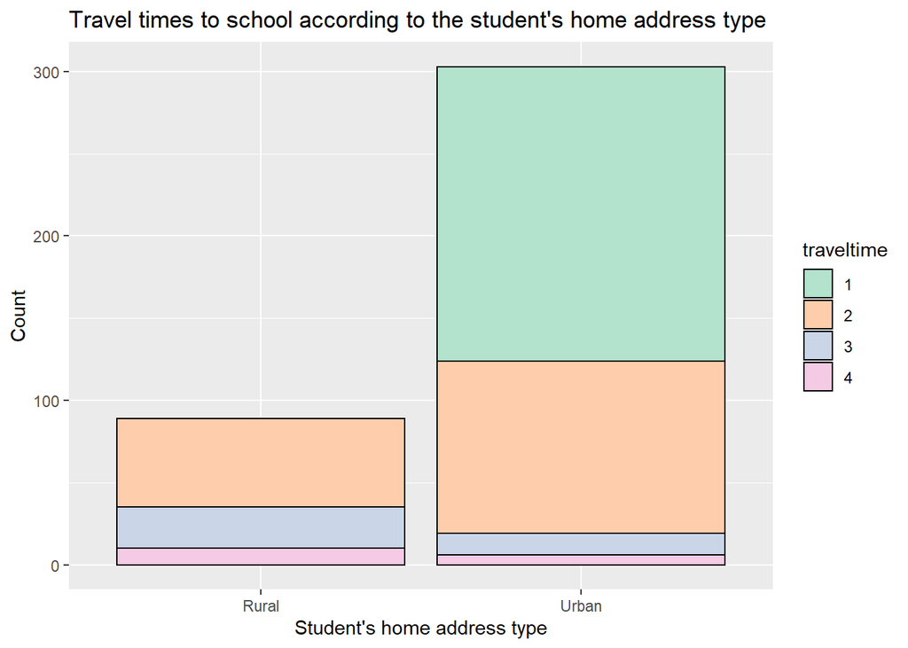

```r
  ggplot(alcohol_data_small , mapping = aes(x = address, fill = traveltime)) +
  geom_bar(position = "identity",color="black") +
  scale_fill_brewer(palette = "Pastel2")+
  labs( x = "Student's home address type",
        y = "Count",
        title = "Travel times to school according to the student's home address type")
```

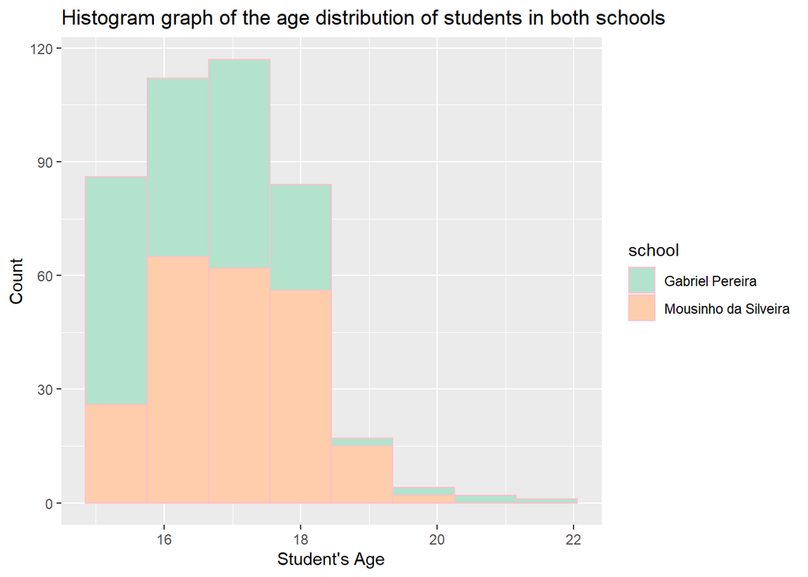

```r
  ggplot(alcohol_data_small, aes(age,fill=school)) +
  geom_histogram(position="identity",binwidth=0.9,color="pink") +
  scale_fill_brewer(palette = "Pastel2")+
  ggtitle("Histogram graph of the age distribution of students in both schools") +
  xlab("Student's Age") +
  ylab("Count")
```

Most students at the school are between the ages of 16 and 18.Very few students go to school after the age of 20.

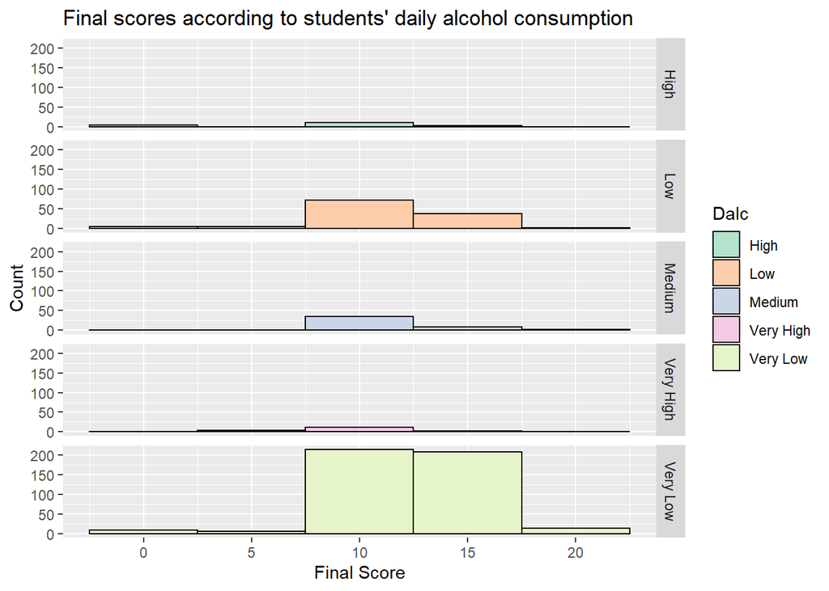

```r
  ggplot(alcohol_data_small, aes(G3, fill=Dalc)) +
  geom_histogram(position="identity", binwidth=5,color="black") +
  scale_fill_brewer(palette = "Pastel2")+
  facet_grid(Dalc ~ .) +
  ggtitle("Final scores according to students' daily alcohol consumption") +
  xlab("Final Score") +
  ylab("Count")
```

I examined the final scores of the students according to their daily alcohol consumption. At the 5th level, that is, the final scores of those who consume alcohol at a very high level decrease as much.

#### B) Draw a *boxplot* and comment about the distribution and outliers.

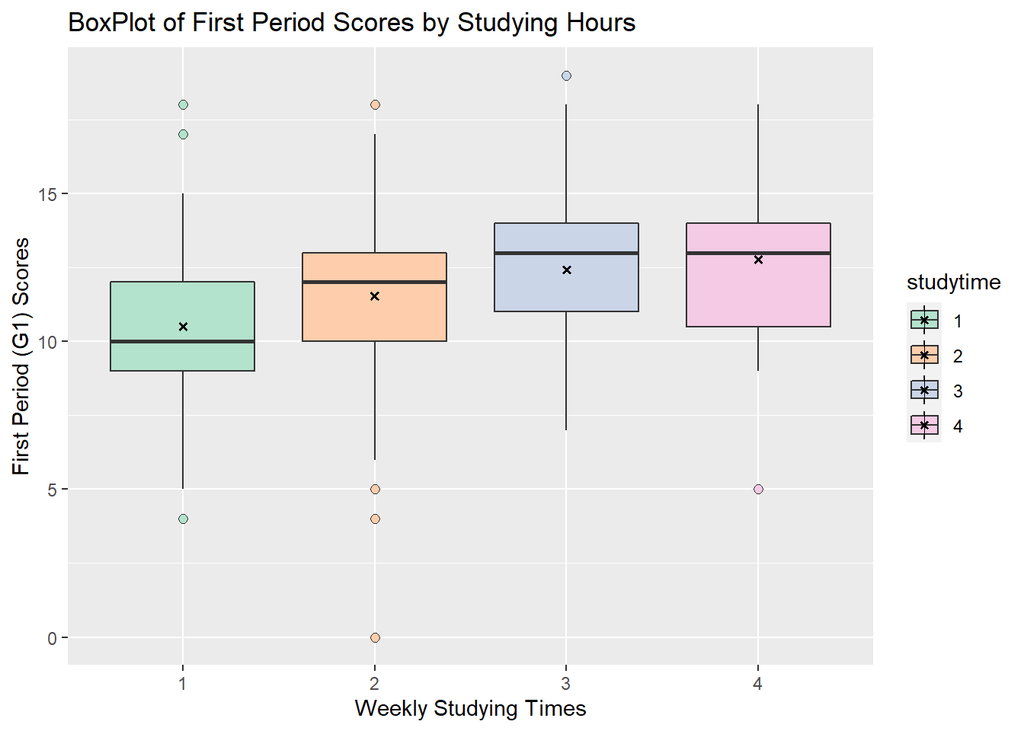

```r
  ggplot(alcohol_data_small, mapping = aes(x = studytime, y = G1 , fill=studytime)) +
  geom_boxplot(outlier.size = 2 ,outlier.shape = 21)+
  stat_summary(fun.y = "mean",shape=4,size=0.2)+
  labs(title = "BoxPlot of First Period Scores by Studying Hours", x="Weekly Studying Times", y="First Period (G1) Scores")+
  scale_fill_brewer(palette = "Pastel2")
```

I have obtained a box chart where we can comment on the scores of the students in the first exam according to their weekly study time.

While the 4th value, that is, those who work more than 10 hours a week, got a higher score in the exam, the 1st value, that is, those who work less than 2 hours per week, gathered around the lower score.

In those with the 2nd value, that is, those who work between 2 and 5 hours a week, there are values that are much higher and lower than the average. These are outlier values.

In addition, those with the most weekly working hours have the highest average score.